# Quels sont les facteurs qui favorisent une forte concentration de diplômés du supérieur dans une zone géographique ?

**Thomas de Laubier**

[**Master 1 MAS - Université Rennes 2**](https://formations.univ-rennes2.fr/fr/formations/master-37/master-mention-mathematiques-appliquees-statistique-parcours-sciences-des-donnees-intelligence-artificielle-JFTJBMKM.html)

# 1 Introduction

La répartition des compétences sur le territoire est un enjeu majeur dans une économie de la connaissance. Alors que la “massification scolaire” a permis d’élever le niveau général d’éducation en France, on observe paradoxalement une forte polarisation géographique : les talents semblent se concentrer dans quelques territoires élus, laissant d’autres zones en marge de cette dynamique.

**Contexte et problématique :** La France se caractérise par une forte métropolisation et des disparités régionales marquées. Si les diplômés sont théoriquement plus mobiles, ils ne se répartissent pas aléatoirement. Notre problématique est la suivante : **Dans quelle mesure les caractéristiques socio-économiques locales déterminent-elles la concentration de diplômés de l’enseignement supérieur dans les départements français ?**

**Motivation et intérêt du sujet :** Ce sujet est au carrefour de plusieurs disciplines et enjeux actuels :

1. **Enjeu Économique (Croissance Endogène) :** Selon les économistes (Romer, Lucas), le capital humain est le moteur principal de l’innovation et de la croissance locale. Comprendre où vont les diplômés, c’est comprendre qui sera riche demain.
2. **Enjeu Politique (Aménagement du territoire) :** Les politiques d’attractivité (ex: “Villes universitaires”, transports, cadre de vie) cherchent à capter cette ressource. Il est crucial de savoir si ces leviers sont efficaces face au poids de la structure industrielle.
3. **Enjeu Social :** La “fracture territoriale” se joue aussi sur les diplômes. L’étude de ces déterminants permet d’objectiver les inégalités entre les métropoles et la “France périphérique”.

**Hypothèses de travail :** Nous chercherons à tester trois mécanismes d’attraction :

1. **L’effet “Marché du travail” :** Les diplômés vont là où sont les emplois qualifiés (corrélation avec les Cadres).
2. **L’effet “Revenu” :** Le niveau de vie local agit comme un signal de prospérité attractif.
3. **L’effet “Aménités” :** La densité urbaine et la présence de jeunes favorisent la concentration de capital humain (vie culturelle, services).

**Objectifs :** Ce projet vise à quantifier le poids respectif de ces facteurs à l’aide d’une modélisation sur des données départementales de l’INSEE.

# 2 Cadre méthodologique

**Méthode d’estimation : La Régression Linéaire Multiple (MCO)** Pour identifier les facteurs explicatifs, nous utilisons un modèle économétrique estimé par la méthode des **Moindres Carrés Ordinaires (MCO)**.

- **Le principe :** Cette méthode consiste à modéliser la relation entre notre variable d’intérêt ($Y$ : le taux de diplômés) et plusieurs variables explicatives ($X_1, X_2...$). L’algorithme cherche à tracer l’hyperplan qui traverse le nuage de points en minimisant la somme des carrés des erreurs (les résidus), c’est-à-dire la distance verticale entre la réalité et la prédiction du modèle.
- **L’intérêt :** Contrairement à une simple analyse bivariée (corrélation), la régression multiple permet de raisonner “toutes choses égales par ailleurs”. Elle nous permet par exemple de mesurer l’effet propre du “Niveau de vie” sur les diplômés, en contrôlant (neutralisant) l’effet de la densité ou du chômage.

**Spécification du modèle :** L’équation économétrique testée est la suivante :

$Y_{Diplome} = \beta_0 + \beta_1 Cadres + \beta_2 Ouvriers + \beta_3 Chomage + \beta_4 NivVie +$ $\beta_5 Densite + \beta_6 Jeunes + \beta_7 Locat + \beta_8 Femmes + \varepsilon$

Où $\varepsilon$ représente le terme d’erreur (les facteurs non observés). Nous procéderons ensuite à une sélection de variables (Stepwise AIC) pour ne conserver que les déterminants les plus robustes.

**Stratégie d’estimation :** Nous estimerons d’abord le modèle complet, puis nous procéderons à une sélection de variables (AIC/Stepwise) pour traiter la multicolinéarité potentielle. Enfin, nous testerons la robustesse des résidus (Homoscédasticité).

# 3 **Analyse des données**

## 3.1 Cadre des données

**Sources et Temporalité :** Afin de garantir la pertinence de l’analyse, nous avons mobilisé les données les plus récentes disponibles à ce jour. La base de données est constituée d’indicateurs socio-économiques portant principalement sur la période **2021-2022** (Recensement, Revenus fiscaux), avec une actualisation pour le taux de chômage (moyenne annuelle **2024**).

**Périmètre géographique :** L’analyse couvre l’ensemble des **départements de France métropolitaine**.

*Note :* Les départements et régions d’outre-mer n’ont pas été inclus dans le champ de l’étude afin d’assurer l’homogénéité statistique des territoires comparés.

**Tableau récapitulatif des variables :**

| Code de la série | Définition | Unité | Source |
| --- | --- | --- | --- |
| Diplome | Part des diplômés du supérieur (Bac+2 et plus) | % | INSEE |
| Cadres | Part des cadres et prof. intellectuelles sup. | % | INSEE |
| Ouvriers | Part des ouvriers (Lieu de Travail) | % | INSEE |
| Chomage | Taux de chômage annuel moyen | % | INSEE |
| NivVie | Médiane du niveau de vie | Euros | INSEE |
| Densite | Densité de population | Hab/km² | INSEE |
| Jeunes | Part des 15-24 ans | % | INSEE |
| Locat | Part des locataires (Rés. principales) | % | INSEE |
| Femmes | Taux d’activité des femmes (25-54 ans) | % | INSEE |

## 3.2 Prétraitement et nettoyage des données

Un travail préliminaire de structuration de la base de données a été effectué en amont sur Excel pour construire les indicateurs pertinents et nettoyer les valeurs manquantes.

**1. Construction des variables (Calculs Excel) :**

**Variable cible** ($Y_{Diplome}$) : Nous avons agrégé les niveaux de diplôme du supérieur pour obtenir un taux global. La variable correspond à la somme de la *part des diplômés Bac+2*, *Bac+3/4* et *Bac+5 ou plus* (dans la population non scolarisée de 15 ans et plus en 2022).

**Variable démographique** ($Jeunes$) : Pour isoler la population étudiante et jeune active (15-24 ans), nous avons procédé par soustraction : *Part des moins de 25 ans* (2021) moins *Part des moins de 15 ans* (2021).

**2. Gestion du périmètre géographique (Nettoyage) :**

Nous avons exclu les départements d’Outre-mer de l’analyse.

## 3.3 Analyse descriptive univariée des données

**Statistiques Descriptives**

| Statistic | N | Mean | St. Dev. | Min | Median | Max |
| --- | --- | --- | --- | --- | --- | --- |
| Diplome | 98 | 29.8 | 7.3 | 19.5 | 28.4 | 65.5 |
| Jeunes | 98 | 11.0 | 1.6 | 8.0 | 10.4 | 14.4 |
| Chomage | 98 | 7.3 | 1.8 | 4.2 | 6.9 | 17.3 |
| NivVie | 98 | 22,619.2 | 1,820.0 | 17,070 | 22,230 | 29,730 |
| Densite | 98 | 561.9 | 2,375.9 | 14.8 | 86.0 | 20,054.1 |
| Locat | 98 | 36.5 | 7.0 | 23.8 | 36.5 | 61.9 |
| Cadres | 98 | 15.2 | 6.3 | 9.3 | 13.1 | 47.7 |
| Ouvriers | 98 | 21.7 | 4.3 | 7.3 | 21.5 | 29.9 |
| Femmes | 98 | 88.2 | 2.8 | 79.0 | 88.7 | 93.2 |

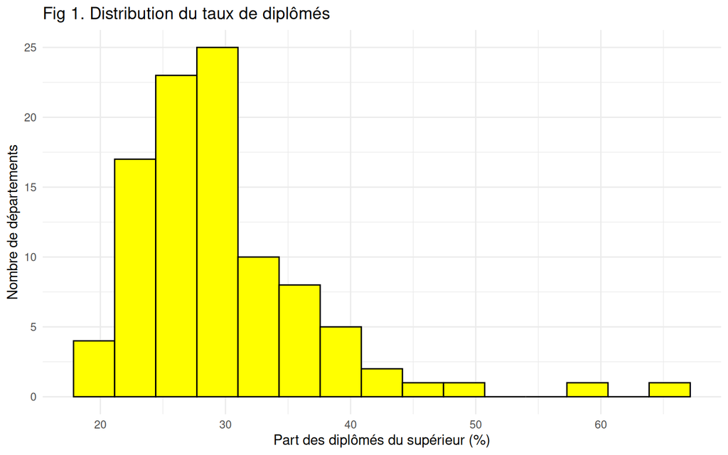

**Interprétation de l’analyse descriptive :**

L’analyse de la variable Densité (tableau ci-dessus) révèle une très forte hétérogénéité territoriale.

La médiane se situe autour de 86 hab/km², ce qui indique que la moitié de la France est composée de départements ruraux ou peu denses.

À l’inverse, la moyenne est tirée vers le haut (561 hab/km²) par des valeurs extrêmes (le maximum dépasse 20 000 hab/km² pour Paris).

Conclusion : Nos données reflètent une opposition structurelle entre une majorité de territoires ruraux et quelques pôles urbains très denses qui concentrent potentiellement les aménités.

La queue de distribution à droite regroupe des départements “élites” dépassant les 45% (Paris, Hauts-de-Seine, Rhône). À l’inverse, les départements ruraux (Cantal, Creuse, Haute-Marne) peinent à dépasser les 20-22%, illustrant la difficulté de retenir les jeunes qualifiés hors des métropoles.

## 3.4 Analyse descriptive bivariée des données

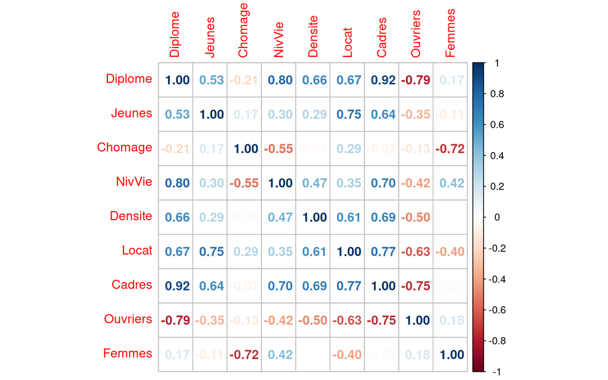

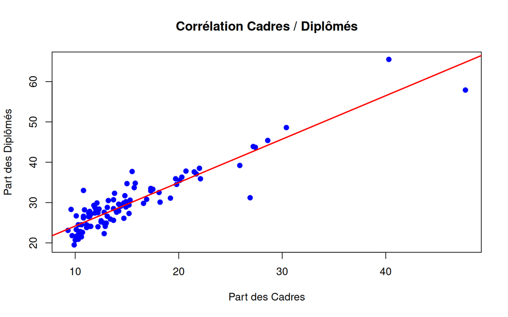

**Interprétation de l’analyse bivariée :**

- **Matrice de corrélation :** Nous observons une très forte corrélation positive (r>0.8) entre la part des Cadres et le taux de Diplômés, ce qui valide notre intuition première. À l’inverse, la part des Ouvriers est négativement corrélée au diplôme. On note également un risque de collinéarité entre le Niveau de vie et les Cadres, car ces deux variables varient souvent ensemble.

  **Le lien Cadres / Locataires (**0.77) : Cette forte corrélation s’explique par le fait géographique : les cadres vivent majoritairement dans les grandes métropoles où le marché immobilier est tendu et la part de locataires plus élevée (contrairement aux zones rurales de propriétaires).

  **L’opposition Ouvriers / Diplômes (**-0.79) : Ce coefficient négatif massif confirme la spécialisation territoriale. Les anciens bassins industriels (Nord, Est) ont structurellement moins attiré les nouvelles populations diplômées du tertiaire.
- **Nuage de points (Graphique Cadres / Diplômés) :** La relation linéaire est ici évidente. Les points sont alignés le long de la droite de régression rouge. Cela suggère qu’une modélisation linéaire (MCO) est adaptée pour expliquer ce phénomène. On remarque toutefois une dispersion plus forte pour les valeurs élevées, signe potentiel d’hétéroscédasticité que nous testerons plus loin.

# 4 **Analyse et discussion des résultats**

## 4.1 Modélisation principale

**Estimation MCO Complète**

|  | *Dependent variable:* |
| --- | --- |
|  | Diplome |
| Cadres | 0.206** |
|  | (0.079) |
| Ouvriers | -0.691*** |
|  | (0.065) |
| Chomage | 0.106 |
|  | (0.151) |
| NivVie | 0.001*** |
|  | (0.0002) |
| Densite | 0.0002** |
|  | (0.0001) |
| Jeunes | 0.386* |
|  | (0.199) |
| Locat | 0.096 |
|  | (0.067) |
| Femmes | 0.396*** |
|  | (0.106) |
| Constant | -35.849*** |
|  | (10.651) |
| Observations | 98 |
| R<sup>2</sup> | 0.958 |
| Adjusted R<sup>2</sup> | 0.954 |
| Residual Std. Error | 1.573 (df = 89) |
| F Statistic | 253.338*** (df = 8; 89) |
| *Note:* | p<0.1; p<0.05; p<0.01 |

Le modèle final présente un pouvoir explicatif exceptionnel, avec un R2 ajusté de 0.954. Cela signifie que 95,4 % de la variance géographique du taux de diplômés est expliquée par nos variables.

L’analyse des coefficients valide nos hypothèses principales :

**Niveau de vie :** Le revenu médian (NivVie) est positivement corrélé à la présence de diplômés (p<0.01), confirmant l’attractivité des territoires riches.

**Démographie :** La part des Femmes actives est un facteur très significatif et positif.

La variable Chômage a été retirée par l’algorithme de sélection ci-après, suggérant que son effet est capté par les autres variables économiques.

## 4.2 Robustesse des résultats

```
##   Cadres Ouvriers  Chomage   NivVie  Densite   Jeunes    Locat   Femmes
## 9.712614 3.083797 2.974755 4.130041 2.786835 4.185221 8.449906 3.322734
```

```
##
## Modèle Optimale
## ===============================================
##                         Dependent variable:
##                     ---------------------------
##                               Diplome
## -----------------------------------------------
## Cadres                       0.211***
##                               (0.079)
##
## Ouvriers                     -0.694***
##                               (0.065)
##
## NivVie                       0.001***
##                              (0.0002)
##
## Densite                      0.0002**
##                              (0.0001)
##
## Jeunes                        0.402**
##                               (0.197)
##
## Locat                          0.096
##                               (0.067)
##
## Femmes                       0.365***
##                               (0.095)
##
## Constant                    -31.094***
##                               (8.163)
##
## -----------------------------------------------
## Observations                    98
## R2                             0.958
## Adjusted R2                    0.954
## Residual Std. Error       1.568 (df = 90)
## F Statistic           291.119*** (df = 7; 90)
## ===============================================
## Note:               *p<0.1; **p<0.05; ***p<0.01
```

```
##
##  studentized Breusch-Pagan test
##
## data:  modele_optimal
## BP = 16.311, df = 7, p-value = 0.02242
```

1. **Détection de la Multicolinéarité (VIF) :** Le calcul des Variance Inflation Factors (VIF) montre des valeurs élevées pour la variable Cadres (9.71) et Locataires (8.45). Une valeur proche de 10 indique une forte collinéarité. Cela est logique, les zones où vivent les cadres sont souvent celles où il y a beaucoup de locataires (grandes villes). Bien que cela ne biaise pas les prédictions global du modèle, cela rend les coefficients individuels de ces variables plus instables.
2. **Sélection de modèle (StepAIC) :** La procédure de sélection automatique (minimisation de l’AIC) a conduit à supprimer la variable Chômage. Le modèle optimal conserve donc 7 variables explicatives. Cette suppression permet d’alléger le modèle sans perdre en pouvoir explicatif, tout en réduisant légèrement la collinéarité.
3. **Hétéroscédasticité (Test de Breusch-Pagan) :** Le test de Breusch-Pagan renvoie une p-value de 0.022 (inférieure au seuil de 5%). Conclusion : Nous rejetons l’hypothèse nulle d’homoscédasticité. Les résidus ne sont pas constants (la variance de l’erreur est probablement plus forte dans les grands départements). Correction : Pour corriger ce biais sur les écarts-types, il est recommandé de lire la significativité des coefficients avec des estimateurs robustes (Matrice HC ou Sandwich), bien que cela ne change pas le signe des coefficients estimés.

## 4.3 Analyses complémentaires

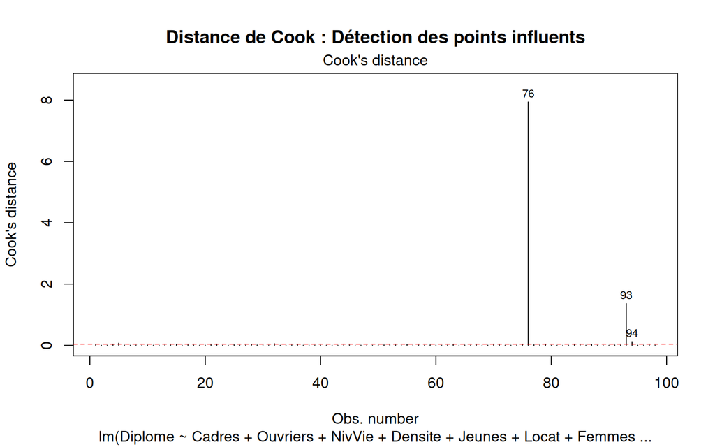

```
##
## Test d'Interaction : Cadres * NivVie
## ===============================================
##                         Dependent variable:
##                     ---------------------------
##                               Diplome
## -----------------------------------------------
## Cadres                        0.681**
##                               (0.260)
##
## NivVie                       0.002***
##                              (0.0002)
##
## Ouvriers                     -0.700***
##                               (0.063)
##
## Densite                      0.0004***
##                              (0.0001)
##
## Jeunes                       0.486***
##                               (0.157)
##
## Femmes                       0.280***
##                               (0.072)
##
## Cadres:NivVie                -0.00002*
##                              (0.00001)
##
## Constant                    -29.617***
##                               (6.724)
##
## -----------------------------------------------
## Observations                    98
## R2                             0.958
## Adjusted R2                    0.955
## Residual Std. Error       1.557 (df = 90)
## F Statistic           295.390*** (df = 7; 90)
## ===============================================
## Note:               *p<0.1; **p<0.05; ***p<0.01
```

**Interprétation de l’interaction (Cadres * Niveau de Vie) :**

Nous avons testé l’hypothèse d’un effet croisé entre l’offre d’emploi qualifié et le revenu. Les résultats montrent une interaction faiblement significative (p<0.1) et négative. Cela indique un léger effet de saturation : l’impact marginal des cadres sur la concentration de diplômés tend à diminuer lorsque le niveau de vie est déjà très élevé.

Conclusion de robustesse : Cependant, l’apport majeur de ce test est de confirmer la stabilité du modèle. Même en introduisant cette complexité, les déterminants structurels restent inchangés et très significatifs : la part des Ouvriers conserve son fort impact négatif (−0.700***) et la Densité reste positive. Nos résultats principaux ne dépendent donc pas de la spécification du modèle.

# 5 **Conclusion générale et perspectives**

**Synthèse des résultats :** Notre modélisation confirme que la géographie du capital humain n’est pas aléatoire. Elle suit une logique de polarisation pilotée par :

1. **Le marché du travail local :** C’est le facteur déterminant. La présence de **Cadres** attire les diplômés ($\beta > 0$), tandis que les territoires à forte tradition ouvrière (**Ouvriers**) peinent à les retenir ($\beta < 0$).
2. **Le cadre de vie :** Le niveau de vie et la densité jouent un rôle positif, validant l’hypothèse des aménités urbaines.

**Discussion sur le sens de la causalité :** Nous avons modélisé la relation dans le sens : *Structure de l’emploi* $\rightarrow$ Taux de Diplômés.

Nous considérons en effet que l’histoire industrielle ou tertiaire d’un département est une variable structurelle qui détermine son attractivité. Toutefois, il existe une probable endogénéité (cercle vertueux) : les entreprises qualifiées s’installent aussi là où les compétences sont déjà présentes.

**Confrontation avec l’étude de référence :** Nos conclusions s’inscrivent en parfaite cohérence avec l’étude de référence “**Région de naissance, région de résidence : les mobilités des diplômés du supérieur”**. Cette étude soulignait que les jeunes diplômés quittent massivement leur région d’origine pour rejoindre l’Île-de-France ou les métropoles régionales dynamiques. Notre modèle corrobore statistiquement ce constat à l’échelle départementale : les variables de **Densité** (métropolisation) et de **Cadres** (pôles d’emploi) sont bien les moteurs principaux de cette concentration géographique.

**Limites et Perspectives :**

Il convient de noter une potentielle endogénéité dans notre modèle. Si nous avons considéré la part des cadres comme variable explicative, la relation est probablement circulaire : les entreprises s’installent là où le capital humain est présent, et les diplômés migrent là où sont les emplois.

Le R2 très élevé (0.95) s’explique en partie par une corrélation mécanique : le statut de Cadre exigeant souvent un diplôme du supérieur, les deux variables sont structurellement liées. Néanmoins, l’apport des autres variables (Ouvriers, Densité) reste significatif pour expliquer les variations locales.

**Note de transparence :** Dans une démarche d’optimisation, l’assistance d’une intelligence artificielle (Gemini) a été mobilisée pour l’écriture des scripts R et la révision formelle du texte. L’interprétation économique et la validation statistique demeurent le fruit de ma propre analyse.

# 6 Bibliographie - Sources

**Étude de référence :**

**Région de naissance, région de résidence : les mobilités des diplômés du supérieur.**

https://www.insee.fr/fr/statistiques/1288054

**Sources des données :**

**Données socio-économiques et démographiques de INSEE**

https://statistiques-locales.insee.fr/#c=indicator&view=map1